# Project Introduction to Natural Language Processing

# Andres Delgadillo

## 1. Twitter US Airline Sentiment

### 1.1 Objective

- Identify and classify the sentiment of twitter post about airlines services

### 1.2 Data Dictionary

- tweet_id
- airline_sentiment
- airline_sentiment_confidence
- negativereason
- negativereason_confidence
- airline
- airline_sentiment_gold
- name
- negativereason_gold
- retweet_count
- text
- tweet_coord
- tweet_created
- tweet_location
- user_timezone

### 1.3 Questions to be answered

- What are the main words that identify the positive and negative sentiment for US Airline Tweets?
- What is the perception about the service of US Airlines?

### 1.4 Import packages and turnoff warnings

```python
import warnings
warnings.filterwarnings("ignore")

import numpy as np                                  #for large and multi-dimensional arrays
import pandas as pd                                 #for data manipulation and analysis
pd.set_option('display.max_colwidth', None)
import matplotlib.pyplot as plt
import seaborn as sns

from wordcloud import WordCloud,STOPWORDS

import nltk                                         #Natural language processing tool-kit
from nltk.corpus import stopwords                   #Stopwords corpus
from nltk.tokenize import word_tokenize, sent_tokenize  # Import Tokenizer.
from nltk.stem import PorterStemmer                 # Stemmer
from nltk.stem.wordnet import WordNetLemmatizer         # Import Lemmatizer.

import re, string, unicodedata                          # Import Regex, string and unicodedata.
import contractions                                     # Import contractions library.
from bs4 import BeautifulSoup                           # Import BeautifulSoup.

from sklearn.feature_extraction.text import CountVectorizer          #For Bag of words
from sklearn.feature_extraction.text import TfidfVectorizer          #For TF-IDF
from sklearn.model_selection import KFold, StratifiedKFold, cross_val_score
from sklearn.metrics import f1_score,accuracy_score, recall_score, precision_score, roc_auc_score, roc_curve, confusion_matrix, precision_recall_curve
from sklearn.model_selection import train_test_split, RandomizedSearchCV
from sklearn.ensemble import RandomForestClassifier

from xgboost import XGBClassifier
```

## 2 Import dataset and quality of data

```python
# read data from csv file
data = pd.read_csv('Tweets.csv')
```

```python
# get columns
data.columns
```

```
Index(['tweet_id', 'airline_sentiment', 'airline_sentiment_confidence',
       'negativereason', 'negativereason_confidence', 'airline',
       'airline_sentiment_gold', 'name', 'negativereason_gold',
       'retweet_count', 'text', 'tweet_coord', 'tweet_created',
       'tweet_location', 'user_timezone'],
      dtype='object')
```

```python
# get size of dataset
data.shape
```

```
(14640, 15)
```

```python
# check dataset information
data.info()
```

```
<class 'pandas.core.frame.DataFrame'>
RangeIndex: 14640 entries, 0 to 14639
Data columns (total 15 columns):
 #   Column                        Non-Null Count  Dtype
---  ------                        --------------  -----
 0   tweet_id                      14640 non-null  int64
 1   airline_sentiment             14640 non-null  object
 2   airline_sentiment_confidence  14640 non-null  float64
 3   negativereason                9178 non-null   object
 4   negativereason_confidence     10522 non-null  float64
 5   airline                       14640 non-null  object
 6   airline_sentiment_gold        40 non-null     object
 7   name                          14640 non-null  object
 8   negativereason_gold           32 non-null     object
 9   retweet_count                 14640 non-null  int64
 10  text                          14640 non-null  object
 11  tweet_coord                   1019 non-null   object
 12  tweet_created                 14640 non-null  object
 13  tweet_location                9907 non-null   object
 14  user_timezone                 9820 non-null   object
dtypes: float64(2), int64(2), object(11)
memory usage: 1.7+ MB
```

```python
# check dataset missing values
total = data.isnull().sum().sort_values(ascending=False) # total number of null values
print(total)
```

```
negativereason_gold             14608
airline_sentiment_gold          14600
tweet_coord                     13621
negativereason                   5462
user_timezone                    4820
tweet_location                   4733
negativereason_confidence        4118
tweet_id                            0
airline_sentiment                   0
airline_sentiment_confidence        0
airline                             0
name                                0
retweet_count                       0
text                                0
tweet_created                       0
dtype: int64
```

There are several columns with missing data.

- `negativereason_gold`, `airline_sentiment_gold` and `tweet_coord` have more than 93% of missing values

```python
# check for duplicates
data.duplicated().sum()
```

```
36
```

There are 36 rows duplicated. We are going to drop duplicated rows

```python
data.drop_duplicates(keep='first', inplace=True, ignore_index=True)
```

```python
# check dataset information
data.info()
```

```
<class 'pandas.core.frame.DataFrame'>
RangeIndex: 14604 entries, 0 to 14603
Data columns (total 15 columns):
 #   Column                        Non-Null Count  Dtype
---  ------                        --------------  -----
 0   tweet_id                      14604 non-null  int64
 1   airline_sentiment             14604 non-null  object
 2   airline_sentiment_confidence  14604 non-null  float64
 3   negativereason                9159 non-null   object
 4   negativereason_confidence     10503 non-null  float64
 5   airline                       14604 non-null  object
 6   airline_sentiment_gold        40 non-null     object
 7   name                          14604 non-null  object
 8   negativereason_gold           32 non-null     object
 9   retweet_count                 14604 non-null  int64
 10  text                          14604 non-null  object
 11  tweet_coord                   1015 non-null   object
 12  tweet_created                 14604 non-null  object
 13  tweet_location                9881 non-null   object
 14  user_timezone                 9790 non-null   object
dtypes: float64(2), int64(2), object(11)
memory usage: 1.7+ MB
```

## 3 Exploratory Data Analysis

```python
# check first rows of data
data.head()
```

|  | tweet_id | airline_sentiment | airline_sentiment_confidence | negativereason | negativereason_confidence | airline | airline_sentiment_gold | name | negativereason_gold | retweet_count | text | tweet_coord | tweet_created | tweet_location | user_timezone |
| --- | --- | --- | --- | --- | --- | --- | --- | --- | --- | --- | --- | --- | --- | --- | --- |
| 0 | 570306133677760513 | neutral | 1.0000 | NaN | NaN | Virgin America | NaN | cairdin | NaN | 0 | @VirginAmerica What @dhepburn said. | NaN | 2015-02-24 11:35:52 -0800 | NaN | Eastern Time (US & Canada) |
| 1 | 570301130888122368 | positive | 0.3486 | NaN | 0.0000 | Virgin America | NaN | jnardino | NaN | 0 | @VirginAmerica plus you've added commercials to the experience... tacky. | NaN | 2015-02-24 11:15:59 -0800 | NaN | Pacific Time (US & Canada) |
| 2 | 570301083672813571 | neutral | 0.6837 | NaN | NaN | Virgin America | NaN | yvonnalynn | NaN | 0 | @VirginAmerica I didn't today... Must mean I need to take another trip! | NaN | 2015-02-24 11:15:48 -0800 | Lets Play | Central Time (US & Canada) |
| 3 | 570301031407624196 | negative | 1.0000 | Bad Flight | 0.7033 | Virgin America | NaN | jnardino | NaN | 0 | @VirginAmerica it's really aggressive to blast obnoxious "entertainment" in your guests' faces &amp; they have little recourse | NaN | 2015-02-24 11:15:36 -0800 | NaN | Pacific Time (US & Canada) |
| 4 | 570300817074462722 | negative | 1.0000 | Can't Tell | 1.0000 | Virgin America | NaN | jnardino | NaN | 0 | @VirginAmerica and it's a really big bad thing about it | NaN | 2015-02-24 11:14:45 -0800 | NaN | Pacific Time (US & Canada) |

```python
# check last rows of data
data.tail()
```

|  | tweet_id | airline_sentiment | airline_sentiment_confidence | negativereason | negativereason_confidence | airline | airline_sentiment_gold | name | negativereason_gold | retweet_count | text | tweet_coord | tweet_created | tweet_location | user_timezone |
| --- | --- | --- | --- | --- | --- | --- | --- | --- | --- | --- | --- | --- | --- | --- | --- |
| 14599 | 569587686496825344 | positive | 0.3487 | NaN | 0.0000 | American | NaN | KristenReenders | NaN | 0 | @AmericanAir thank you we got on a different flight to Chicago. | NaN | 2015-02-22 12:01:01 -0800 | NaN | NaN |
| 14600 | 569587371693355008 | negative | 1.0000 | Customer Service Issue | 1.0000 | American | NaN | itsropes | NaN | 0 | @AmericanAir leaving over 20 minutes Late Flight. No warnings or communication until we were 15 minutes Late Flight. That's called shitty customer svc | NaN | 2015-02-22 11:59:46 -0800 | Texas | NaN |
| 14601 | 569587242672398336 | neutral | 1.0000 | NaN | NaN | American | NaN | sanyabun | NaN | 0 | @AmericanAir Please bring American Airlines to #BlackBerry10 | NaN | 2015-02-22 11:59:15 -0800 | Nigeria,lagos | NaN |
| 14602 | 569587188687634433 | negative | 1.0000 | Customer Service Issue | 0.6659 | American | NaN | SraJackson | NaN | 0 | @AmericanAir you have my money, you change my flight, and don't answer your phones! Any other suggestions so I can make my commitment?? | NaN | 2015-02-22 11:59:02 -0800 | New Jersey | Eastern Time (US & Canada) |
| 14603 | 569587140490866689 | neutral | 0.6771 | NaN | 0.0000 | American | NaN | daviddtwu | NaN | 0 | @AmericanAir we have 8 ppl so we need 2 know how many seats are on the next flight. Plz put us on standby for 4 people on the next flight? | NaN | 2015-02-22 11:58:51 -0800 | dallas, TX | NaN |

```python
#function to plot the distribution of the feature
def bar_plot(data, feature):
    plot = sns.countplot(y=feature, data=data, order=data[feature].value_counts().index)
    total = len(data)
    for p in plot.patches:
        percentage = '{:.1f}%'.format(100 * p.get_width()/total)
        x = p.get_x() + p.get_width() / 2 - 0.05
        y = p.get_y() + p.get_height()
        plot.annotate(percentage, (x, y),ha="center",
            va="center",
            size=12,
            xytext=(0, 5),
            textcoords="offset points")
    plt.tight_layout()
    plt.show()
```

### 3.1 Airline distribution

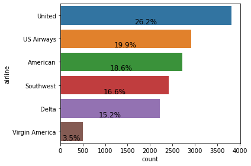

```python
bar_plot(data,'airline')
```

There are 6 airlines. United corresponds to 26% of tweets while Virgin America only to 3.5%

### 3.2 Airline Sentiment distribution

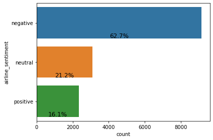

```python
bar_plot(data,'airline_sentiment')
```

There are 3 sentiments

- negative is in 63% of the tweets
- neutral in 21%
- positive in 16%

### 3.3 Airline Sentiment distribution by Airline

```python
# calculate the sentiment distribution by airline in %
df1 = data.groupby('airline')['airline_sentiment'].value_counts(normalize=True)
df1 = df1.mul(100)
df1 = df1.rename('percent').reset_index()
```

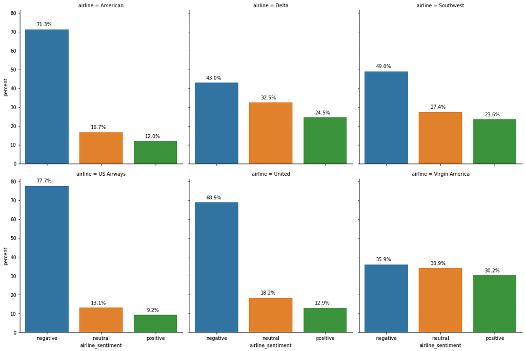

```python
# plot the distributions
g = sns.catplot(x='airline_sentiment',y='percent',col='airline',kind='bar',data=df1, col_wrap=3)
# add labels to the chart
for ax in g.axes.ravel():
    for c in ax.containers:
        for v in c:
            label = f'{(v.get_height()):.1f}%'
            x = v.get_x() + v.get_width() / 2 - 0.05
            y = v.get_y() + v.get_height()
            ax.annotate(label, (x, y), ha = 'center', va = 'center', xytext = (0, 10), textcoords = 'offset points')
```

- American, US Airways and United have the highest proportion of negative sentiments
- Delta and Southwest still have higher proportion of negative sentiments but much lower ratio that American, US Airways and United
- Virgin America have almost a uniform distribution in terms of sentiment

### 3.4 Negative reason distribution

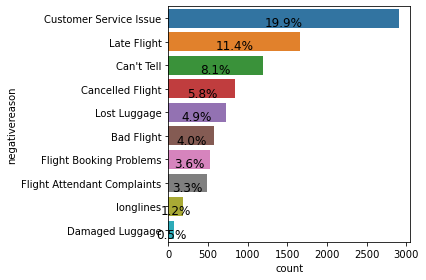

```python
bar_plot(data,'negativereason')
```

There are 10 different negative reasons being `Customer Service Issue` the most common, and `Damage Luggage` the least common

### 3.5 Word cloud graph

#### 3.5.1 Negative sentiment

```python
#creating word cloud for negative reviews
negative_reviews=data[data['airline_sentiment']=='negative']
words = ' '.join(negative_reviews['text'])
cleaned_word_neg = " ".join([word for word in words.split()])
```

```python
wordcloud = WordCloud(stopwords=STOPWORDS,
                      background_color='white',
                      width=3000,
                      height=2500
                     ).generate(cleaned_word_neg)
```

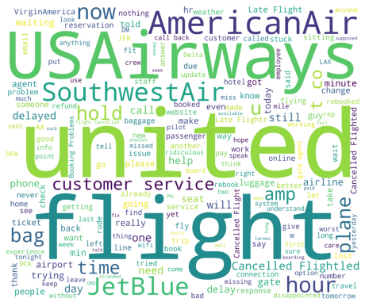

```python
plt.figure(1,figsize=(8, 8))
plt.imshow(wordcloud)
plt.axis('off')
plt.show()
```

It is clear how negative sentiment is associated with united, USAirways, AmericanAir, SouthwestAir and JetBlue. Negative sentiment is also related to canceled flight, customer service, time, hour, bag and plane.

#### 3.5.2 Positive sentiment

```python
#creating word cloud for positive reviews
positive_reviews=data[data['airline_sentiment']=='positive']
words = ' '.join(positive_reviews['text'])
cleaned_word_pos = " ".join([word for word in words.split()])
```

```python
wordcloud = WordCloud(stopwords=STOPWORDS,
                      background_color='white',
                      width=3000,
                      height=2500
                     ).generate(cleaned_word_pos)
```

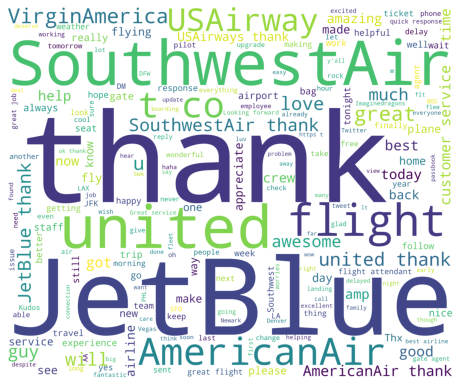

```python
plt.figure(1,figsize=(8, 8))
plt.imshow(wordcloud)
plt.axis('off')
plt.show()
```

Positive sentiment is associated with thank, JetBlue, SouthwestAir, united, USAirway, AmericanAir, VirginAmerica.

#### 3.5.3 Neutral sentiment

```python
#creating word cloud for positive reviews
neutral_reviews=data[data['airline_sentiment']=='neutral']
words = ' '.join(neutral_reviews['text'])
cleaned_word_neu = " ".join([word for word in words.split()])
```

```python
wordcloud = WordCloud(stopwords=STOPWORDS,
                      background_color='white',
                      width=3000,
                      height=2500
                     ).generate(cleaned_word_neu)
```

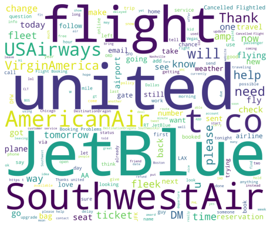

```python
plt.figure(1,figsize=(8, 8))
plt.imshow(wordcloud)
plt.axis('off')
plt.show()
```

Neutral sentiment is associated to JetBlue, united, flight, SouthwestAir, AmericanAir, USAirways,

## 4 Understanding of Data Columns

Now, we are going to keep only `text` and `airline_sentiment` columns

```python
data_clean = data[['text','airline_sentiment']]
```

```python
# get size of dataset
data_clean.shape
```

```
(14604, 2)
```

```python
# check dataset information
data_clean.info()
```

```
<class 'pandas.core.frame.DataFrame'>
RangeIndex: 14604 entries, 0 to 14603
Data columns (total 2 columns):
 #   Column             Non-Null Count  Dtype
---  ------             --------------  -----
 0   text               14604 non-null  object
 1   airline_sentiment  14604 non-null  object
dtypes: object(2)
memory usage: 228.3+ KB
```

```python
# check first rows of data
data_clean.head()
```

|  | text | airline_sentiment |
| --- | --- | --- |
| 0 | @VirginAmerica What @dhepburn said. | neutral |
| 1 | @VirginAmerica plus you've added commercials to the experience... tacky. | positive |
| 2 | @VirginAmerica I didn't today... Must mean I need to take another trip! | neutral |
| 3 | @VirginAmerica it's really aggressive to blast obnoxious "entertainment" in your guests' faces &amp; they have little recourse | negative |
| 4 | @VirginAmerica and it's a really big bad thing about it | negative |

```python
# check last rows of data
data_clean.tail()
```

|  | text | airline_sentiment |
| --- | --- | --- |
| 14599 | @AmericanAir thank you we got on a different flight to Chicago. | positive |
| 14600 | @AmericanAir leaving over 20 minutes Late Flight. No warnings or communication until we were 15 minutes Late Flight. That's called shitty customer svc | negative |
| 14601 | @AmericanAir Please bring American Airlines to #BlackBerry10 | neutral |
| 14602 | @AmericanAir you have my money, you change my flight, and don't answer your phones! Any other suggestions so I can make my commitment?? | negative |
| 14603 | @AmericanAir we have 8 ppl so we need 2 know how many seats are on the next flight. Plz put us on standby for 4 people on the next flight? | neutral |

## 5 Data Pre - Processing

### 5.1 Html tag removal

```python
def strip_html(text):
    soup = BeautifulSoup(text, "html.parser")
    return soup.get_text()

data_clean['text'] = data_clean['text'].apply(lambda x: strip_html(x))
data_clean.head()
```

|  | text | airline_sentiment |
| --- | --- | --- |
| 0 | @VirginAmerica What @dhepburn said. | neutral |
| 1 | @VirginAmerica plus you've added commercials to the experience... tacky. | positive |
| 2 | @VirginAmerica I didn't today... Must mean I need to take another trip! | neutral |
| 3 | @VirginAmerica it's really aggressive to blast obnoxious "entertainment" in your guests' faces & they have little recourse | negative |
| 4 | @VirginAmerica and it's a really big bad thing about it | negative |

### 5.2 Replace contractions

```python
def replace_contractions(text):
    """Replace contractions in string of text"""
    return contractions.fix(text)

data_clean['text'] = data_clean['text'].apply(lambda x: replace_contractions(x))
data_clean.head()
```

|  | text | airline_sentiment |
| --- | --- | --- |
| 0 | @VirginAmerica What @dhepburn said. | neutral |
| 1 | @VirginAmerica plus you have added commercials to the experience... tacky. | positive |
| 2 | @VirginAmerica I did not today... Must mean I need to take another trip! | neutral |
| 3 | @VirginAmerica it is really aggressive to blast obnoxious "entertainment" in your guests' faces & they have little recourse | negative |
| 4 | @VirginAmerica and it is a really big bad thing about it | negative |

### 5.3 Remove numbers

```python
def remove_numbers(text):
  text = re.sub(r'\d+', '', text)
  return text

data_clean['text'] = data_clean['text'].apply(lambda x: remove_numbers(x))
data_clean.head()
```

|  | text | airline_sentiment |
| --- | --- | --- |
| 0 | @VirginAmerica What @dhepburn said. | neutral |
| 1 | @VirginAmerica plus you have added commercials to the experience... tacky. | positive |
| 2 | @VirginAmerica I did not today... Must mean I need to take another trip! | neutral |
| 3 | @VirginAmerica it is really aggressive to blast obnoxious "entertainment" in your guests' faces & they have little recourse | negative |
| 4 | @VirginAmerica and it is a really big bad thing about it | negative |

### Tokenization

```python
data_clean['text'] = data_clean.apply(lambda row: nltk.word_tokenize(row['text']), axis=1) # Tokenization of data
data_clean.head()
```

|  | text | airline_sentiment |
| --- | --- | --- |
| 0 | [@, VirginAmerica, What, @, dhepburn, said, .] | neutral |
| 1 | [@, VirginAmerica, plus, you, have, added, commercials, to, the, experience, ..., tacky, .] | positive |
| 2 | [@, VirginAmerica, I, did, not, today, ..., Must, mean, I, need, to, take, another, trip, !] | neutral |
| 3 | [@, VirginAmerica, it, is, really, aggressive, to, blast, obnoxious, ``, entertainment, '', in, your, guests, ', faces, &, they, have, little, recourse] | negative |
| 4 | [@, VirginAmerica, and, it, is, a, really, big, bad, thing, about, it] | negative |

### 5.5 Remove Special Characters

```python
def remove_non_ascii(words):
    """Remove non-ASCII characters from list of tokenized words"""
    new_words = []
    for word in words:
        new_word = unicodedata.normalize('NFKD', word).encode('ascii', 'ignore').decode('utf-8', 'ignore')
        new_words.append(new_word)
    return new_words

data_clean['text'] = data_clean.apply(lambda row: remove_non_ascii(row['text']), axis=1)
data_clean.head()
```

|  | text | airline_sentiment |
| --- | --- | --- |
| 0 | [@, VirginAmerica, What, @, dhepburn, said, .] | neutral |
| 1 | [@, VirginAmerica, plus, you, have, added, commercials, to, the, experience, ..., tacky, .] | positive |
| 2 | [@, VirginAmerica, I, did, not, today, ..., Must, mean, I, need, to, take, another, trip, !] | neutral |
| 3 | [@, VirginAmerica, it, is, really, aggressive, to, blast, obnoxious, ``, entertainment, '', in, your, guests, ', faces, &, they, have, little, recourse] | negative |
| 4 | [@, VirginAmerica, and, it, is, a, really, big, bad, thing, about, it] | negative |

### 5.6 Remove Punctuations

```python
def remove_punctuation(words):
    """Remove punctuation from list of tokenized words"""
    new_words = []
    for word in words:
        new_word = re.sub(r'[^\w\s]', '', word)
        if new_word != '':
            new_words.append(new_word)
    return new_words

data_clean['text'] = data_clean.apply(lambda row: remove_punctuation(row['text']), axis=1)
data_clean.head()
```

|  | text | airline_sentiment |
| --- | --- | --- |
| 0 | [VirginAmerica, What, dhepburn, said] | neutral |
| 1 | [VirginAmerica, plus, you, have, added, commercials, to, the, experience, tacky] | positive |
| 2 | [VirginAmerica, I, did, not, today, Must, mean, I, need, to, take, another, trip] | neutral |
| 3 | [VirginAmerica, it, is, really, aggressive, to, blast, obnoxious, entertainment, in, your, guests, faces, they, have, little, recourse] | negative |
| 4 | [VirginAmerica, and, it, is, a, really, big, bad, thing, about, it] | negative |

### 5.7 Conversion to lower case

```python
def to_lowercase(words):
    """Convert all characters to lowercase"""
    new_words = []
    for word in words:
        new_word = word.lower()
        new_words.append(new_word)
    return new_words

data_clean['text'] = data_clean.apply(lambda row: to_lowercase(row['text']), axis=1)
data_clean.head()
```

|  | text | airline_sentiment |
| --- | --- | --- |
| 0 | [virginamerica, what, dhepburn, said] | neutral |
| 1 | [virginamerica, plus, you, have, added, commercials, to, the, experience, tacky] | positive |
| 2 | [virginamerica, i, did, not, today, must, mean, i, need, to, take, another, trip] | neutral |
| 3 | [virginamerica, it, is, really, aggressive, to, blast, obnoxious, entertainment, in, your, guests, faces, they, have, little, recourse] | negative |
| 4 | [virginamerica, and, it, is, a, really, big, bad, thing, about, it] | negative |

### 5.8 Remove Stopwords

```python
# List of stopwords
stw = stopwords.words('english')

# Set custom stop-word's list as not, couldn't etc. words matter in Sentiment, so not removing them from original data.
customw = ['not', "couldn't", 'didn', "didn't", 'doesn', "doesn't", 'hadn', "hadn't", 'hasn',
        "hasn't", 'haven', "haven't", 'isn', "isn't", 'ma', 'mightn', "mightn't", 'mustn',
        "mustn't", 'needn', "needn't", 'shan', "shan't", 'shouldn', "shouldn't", 'wasn',
        "wasn't", 'weren', "weren't", 'won', "won't", 'wouldn', "wouldn't"]

stw = list(set(stw) - set(customw))

def remove_stopwords(words):
    """Remove stop words from list of tokenized words"""
    new_words = []
    for word in words:
        if word not in stw:
            new_words.append(word)
    return new_words

data_clean['text'] = data_clean.apply(lambda row: remove_stopwords(row['text']), axis=1)
data_clean.head()
```

|  | text | airline_sentiment |
| --- | --- | --- |
| 0 | [virginamerica, dhepburn, said] | neutral |
| 1 | [virginamerica, plus, added, commercials, experience, tacky] | positive |
| 2 | [virginamerica, not, today, must, mean, need, take, another, trip] | neutral |
| 3 | [virginamerica, really, aggressive, blast, obnoxious, entertainment, guests, faces, little, recourse] | negative |
| 4 | [virginamerica, really, big, bad, thing] | negative |

### 5.9 Lemmatize

```python
lemmatizer = WordNetLemmatizer()

def lemmatize_list(words):
    new_words = []
    for word in words:
      new_words.append(lemmatizer.lemmatize(word, pos='v'))
    return new_words

data_clean['text'] = data_clean.apply(lambda row: lemmatize_list(row['text']), axis=1)
data_clean.head()
```

|  | text | airline_sentiment |
| --- | --- | --- |
| 0 | [virginamerica, dhepburn, say] | neutral |
| 1 | [virginamerica, plus, add, commercials, experience, tacky] | positive |
| 2 | [virginamerica, not, today, must, mean, need, take, another, trip] | neutral |
| 3 | [virginamerica, really, aggressive, blast, obnoxious, entertainment, guests, face, little, recourse] | negative |
| 4 | [virginamerica, really, big, bad, thing] | negative |

### 5.10 Join words

```python
def join_w(words):
    return ' '.join(words)

data_clean['text'] = data_clean.apply(lambda row: join_w(row['text']), axis=1)
data_clean.head()
```

|  | text | airline_sentiment |
| --- | --- | --- |
| 0 | virginamerica dhepburn say | neutral |
| 1 | virginamerica plus add commercials experience tacky | positive |
| 2 | virginamerica not today must mean need take another trip | neutral |
| 3 | virginamerica really aggressive blast obnoxious entertainment guests face little recourse | negative |
| 4 | virginamerica really big bad thing | negative |

## 6 Model Building

### 6.1 Functions to evaluate models

```python
def metrics_score(model, model_name, X_train, y_train, X_test, y_test):
    '''
    Function to calculate different metric scores of the model - Accuracy, Recall, Precision, and F1 score
    model: classifier to predict values of X
    train, test: Independent features
    train_y,test_y: Dependent variable
    '''

    pred_train = model.predict(X_train)
    pred_test = model.predict(X_test)

    score_dict = {'Model':model_name,
                  'Accuracy on training set' : accuracy_score(pred_train,y_train),
                  'Accuracy on validation set': accuracy_score(pred_test,y_test),
                  'Recall on training set': recall_score(y_train,pred_train,average='macro'),
                  'Recall on validation set': recall_score(y_test,pred_test,average='macro'),
                  'Precision on training set': precision_score(y_train,pred_train,average='macro'),
                  'Precision on validation set': precision_score(y_test,pred_test,average='macro'),
                  'F1 on training set': f1_score(y_train,pred_train,average='macro'),
                  'F1 on validation set': f1_score(y_test,pred_test,average='macro')
                 }
    # Create a dataframe with scores
    scores = pd.DataFrame(score_dict,index=[0])
    # return the df
    return scores
```

```python
def make_confusion_matrix(model, X_test, y_test):
    # Test Prediction
    y_test_pred = model.predict(X_test)
    # Confusion matrix normalized per category true value
    cf_matrix = confusion_matrix(y_test, y_test_pred, normalize='true')
    df_cm = pd.DataFrame(cf_matrix,
                         index = ['negative','neutral','positive'],
                         columns = ['negative','neutral','positive'])
    plt.figure(figsize=(8,6))
    sns.heatmap(df_cm, annot=True);
```

## 7 CountVectorizer

```python
countvec = CountVectorizer(max_features=2000)           # Keep only 2000 features
data_countvec = countvec.fit_transform(data_clean['text'])
data_countvec = data_countvec.toarray()
# shape of data
data_countvec.shape
```

```
(14604, 2000)
```

```python
y = data_clean['airline_sentiment']
```

### 7.1 Split data into train and test

```python
# Splitting data into training, validation and test set:
# first we split data into 2 parts, say temporary and test
X_temp, X_test, y_temp, y_test = train_test_split(data_countvec, y, test_size=0.2, random_state=1, stratify=y)

# then we split the temporary set into train and validation
X_train, X_val, y_train, y_val = train_test_split(X_temp, y_temp, test_size=0.25, random_state=1, stratify=y_temp)

print(f'Shape of Training set: {X_train.shape}')
print(f'Shape of Validation set: {X_val.shape}')
print(f'Shape of Test set: {X_test.shape}')
print(f'Percentage of classes in Training set\n{pd.DataFrame(y_train).value_counts(normalize=True)}')
print(f'Percentage of classes in Validation set\n{pd.DataFrame(y_val).value_counts(normalize=True)}')
print(f'Percentage of classes in Test set\n{pd.DataFrame(y_test).value_counts(normalize=True)}')
```

```
Shape of Training set: (8762, 2000)
Shape of Validation set: (2921, 2000)
Shape of Test set: (2921, 2000)
Percentage of classes in Training set
airline_sentiment
negative             0.62714
neutral              0.21171
positive             0.16115
dtype: float64
Percentage of classes in Validation set
airline_sentiment
negative             0.627182
neutral              0.211571
positive             0.161246
dtype: float64
Percentage of classes in Test set
airline_sentiment
negative             0.627182
neutral              0.211571
positive             0.161246
dtype: float64
```

- Training and test set have similar ratios of classes

### 7.2 Random Forest Model

Now, we are going to build the first classification model for CountVectorizer set using a Random Forest Classifier

```python
model_rf_count = RandomForestClassifier(random_state=1)
model_rf_count.fit(X_train,y_train)
```

```
RandomForestClassifier(random_state=1)
```

```python
# Result metrics
results_countvec_rf = metrics_score(model_rf_count, 'Count Vectorizer Random Forest', X_train, y_train, X_val, y_val)
results_countvec_rf
```

|  | Model | Accuracy on training set | Accuracy on validation set | Recall on training set | Recall on validation set | Precision on training set | Precision on validation set | F1 on training set | F1 on validation set |
| --- | --- | --- | --- | --- | --- | --- | --- | --- | --- |
| 0 | Count Vectorizer Random Forest | 0.994294 | 0.753851 | 0.99277 | 0.651921 | 0.990348 | 0.691756 | 0.991553 | 0.668686 |

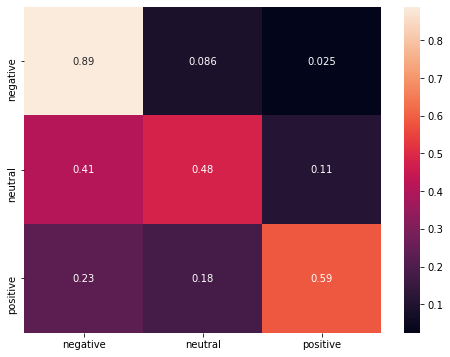

```python
# Confusion matrix
make_confusion_matrix(model_rf_count, X_val, y_val)
```

This model is overfitting. Metrics in training set are very high but decrease significantly on validation set

### 7.3 XGBoost Classifier Model

Now, we are going to use a XGBoost Classifier Model

```python
model_xgb_count = XGBClassifier(random_state=1, eval_metric='logloss')
model_xgb_count.fit(X_train,y_train)
```

```
XGBClassifier(base_score=0.5, booster='gbtree', colsample_bylevel=1,
              colsample_bynode=1, colsample_bytree=1, eval_metric='logloss',
              gamma=0, gpu_id=-1, importance_type='gain',
              interaction_constraints='', learning_rate=0.300000012,
              max_delta_step=0, max_depth=6, min_child_weight=1, missing=nan,
              monotone_constraints='()', n_estimators=100, n_jobs=8,
              num_parallel_tree=1, objective='multi:softprob', random_state=1,
              reg_alpha=0, reg_lambda=1, scale_pos_weight=None, subsample=1,
              tree_method='exact', validate_parameters=1, verbosity=None)
```

```python
# Result metrics
results_countvec = metrics_score(model_xgb_count, 'Count Vectorizer XGBoost', X_train, y_train, X_val, y_val)
results_countvec
```

|  | Model | Accuracy on training set | Accuracy on validation set | Recall on training set | Recall on validation set | Precision on training set | Precision on validation set | F1 on training set | F1 on validation set |
| --- | --- | --- | --- | --- | --- | --- | --- | --- | --- |
| 0 | Count Vectorizer XGBoost | 0.860192 | 0.770284 | 0.796466 | 0.673229 | 0.839645 | 0.715296 | 0.815753 | 0.69104 |

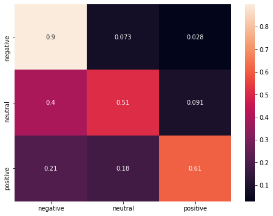

```python
# Confusion matrix
make_confusion_matrix(model_xgb_count, X_val, y_val)
```

This model improves the metrics on validation set, but it still present overfitting issues

### 7.4 Tuned XGBoost

Now, we are going to tuned the XGBoost model in order to improve the metrics on validation set

```python
# dictionary with parameters
param_grid = {
    'n_estimators': np.arange(10,200,10),
    'subsample': np.arange(0.1,1,0.1),
    'learning_rate': np.arange(0.1,2,0.1),
    'gamma': np.arange(0.1,3,0.1),
    'colsample_bytree': np.arange(0.1,1,0.1),
    'colsample_bylevel': np.arange(0.1,1,0.1),
}

# Run random search
grid_obj = RandomizedSearchCV(estimator=model_xgb_count, param_distributions=param_grid, n_iter=50, scoring='accuracy',
                              cv=5, random_state=1, n_jobs = -1, verbose=2)
grid_obj.fit(X_train, y_train)

# Get the best combination of parameters
xgb_estimator = grid_obj.best_estimator_

# Fit the best algorithm to the data.
xgb_estimator.fit(X_train, y_train)
```

```
Fitting 5 folds for each of 50 candidates, totalling 250 fits
```

```
XGBClassifier(base_score=0.5, booster='gbtree', colsample_bylevel=0.1,
              colsample_bynode=1, colsample_bytree=0.6, eval_metric='logloss',
              gamma=0.7000000000000001, gpu_id=-1, importance_type='gain',
              interaction_constraints='', learning_rate=0.4, max_delta_step=0,
              max_depth=6, min_child_weight=1, missing=nan,
              monotone_constraints='()', n_estimators=170, n_jobs=8,
              num_parallel_tree=1, objective='multi:softprob', random_state=1,
              reg_alpha=0, reg_lambda=1, scale_pos_weight=None, subsample=0.8,
              tree_method='exact', validate_parameters=1, verbosity=None)
```

```python
# Result metrics
results_countvec_tuned = metrics_score(xgb_estimator, 'Count Vectorizer Tuned XGBoost', X_train, y_train, X_val, y_val)
results_countvec_tuned
```

|  | Model | Accuracy on training set | Accuracy on validation set | Recall on training set | Recall on validation set | Precision on training set | Precision on validation set | F1 on training set | F1 on validation set |
| --- | --- | --- | --- | --- | --- | --- | --- | --- | --- |
| 0 | Count Vectorizer Tuned XGBoost | 0.859735 | 0.780555 | 0.7996 | 0.691135 | 0.836463 | 0.726208 | 0.81628 | 0.706492 |

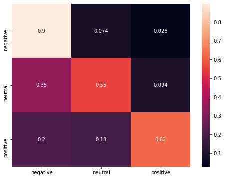

```python
# Confusion matrix
make_confusion_matrix(xgb_estimator, X_val, y_val)
```

## 8 Tf-IDF vectorizer

```python
tfidfvec = TfidfVectorizer(max_features=2000)
data_tfidfvec = tfidfvec.fit_transform(data_clean['text'])
data_tfidfvec = data_tfidfvec.toarray()
# shape of data
data_tfidfvec.shape
```

```
(14604, 2000)
```

### 8.1 Split data into train and test

```python
# Splitting data into training, validation and test set:
# first we split data into 2 parts, say temporary and test
X_temp2, X_test2, y_temp2, y_test2 = train_test_split(data_tfidfvec, y, test_size=0.2, random_state=1, stratify=y)

# then we split the temporary set into train and validation
X_train2, X_val2, y_train2, y_val2 = train_test_split(X_temp2, y_temp2, test_size=0.25, random_state=1, stratify=y_temp2)

print(f'Shape of Training set: {X_train2.shape}')
print(f'Shape of Validation set: {X_val2.shape}')
print(f'Shape of Test set: {X_test2.shape}')
print(f'Percentage of classes in Training set\n{pd.DataFrame(y_train2).value_counts(normalize=True)}')
print(f'Percentage of classes in Validation set\n{pd.DataFrame(y_val2).value_counts(normalize=True)}')
print(f'Percentage of classes in Test set\n{pd.DataFrame(y_test2).value_counts(normalize=True)}')
```

```
Shape of Training set: (8762, 2000)
Shape of Validation set: (2921, 2000)
Shape of Test set: (2921, 2000)
Percentage of classes in Training set
airline_sentiment
negative             0.62714
neutral              0.21171
positive             0.16115
dtype: float64
Percentage of classes in Validation set
airline_sentiment
negative             0.627182
neutral              0.211571
positive             0.161246
dtype: float64
Percentage of classes in Test set
airline_sentiment
negative             0.627182
neutral              0.211571
positive             0.161246
dtype: float64
```

### 8.2 Random Forest Model

We are going to use a Random Forest Classifier using the TfidfVectorizer set

```python
model_rf_tfidf = RandomForestClassifier(random_state=1)
model_rf_tfidf.fit(X_train2,y_train2)
```

```
RandomForestClassifier(random_state=1)
```

```python
# Result metrics
results_tfidf_rf = metrics_score(model_rf_tfidf, 'Tf-IDF Vectorizer Random Forest', X_train2, y_train2, X_val2, y_val2)
results_tfidf_rf
```

|  | Model | Accuracy on training set | Accuracy on validation set | Recall on training set | Recall on validation set | Precision on training set | Precision on validation set | F1 on training set | F1 on validation set |
| --- | --- | --- | --- | --- | --- | --- | --- | --- | --- |
| 0 | Tf-IDF Vectorizer Random Forest | 0.994179 | 0.75659 | 0.992828 | 0.620299 | 0.989889 | 0.71797 | 0.991351 | 0.652437 |

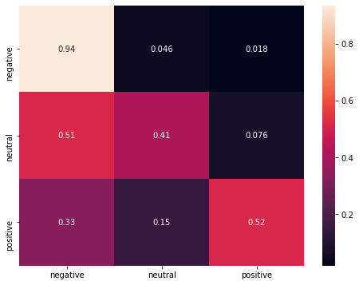

```python
# Confusion matrix
make_confusion_matrix(model_rf_tfidf, X_val2, y_val2)
```

This model presents overfitting. Metrics on validation set are much lower than on training set

### 8.3 XGBoost Classifier Model

Now, we are going to use a XGBoost classifier model

```python
model_xgb_tfidf = XGBClassifier(random_state=1, eval_metric='logloss')
model_xgb_tfidf.fit(X_train2,y_train2)
```

```
XGBClassifier(base_score=0.5, booster='gbtree', colsample_bylevel=1,
              colsample_bynode=1, colsample_bytree=1, eval_metric='logloss',
              gamma=0, gpu_id=-1, importance_type='gain',
              interaction_constraints='', learning_rate=0.300000012,
              max_delta_step=0, max_depth=6, min_child_weight=1, missing=nan,
              monotone_constraints='()', n_estimators=100, n_jobs=8,
              num_parallel_tree=1, objective='multi:softprob', random_state=1,
              reg_alpha=0, reg_lambda=1, scale_pos_weight=None, subsample=1,
              tree_method='exact', validate_parameters=1, verbosity=None)
```

```python
# Result metrics
results_tfidf = metrics_score(model_xgb_tfidf, 'Tf-IDF Vectorizer XGBoost', X_train2, y_train2, X_val2, y_val2)
results_tfidf
```

|  | Model | Accuracy on training set | Accuracy on validation set | Recall on training set | Recall on validation set | Precision on training set | Precision on validation set | F1 on training set | F1 on validation set |
| --- | --- | --- | --- | --- | --- | --- | --- | --- | --- |
| 0 | Tf-IDF Vectorizer XGBoost | 0.878567 | 0.767545 | 0.816876 | 0.654195 | 0.869569 | 0.718643 | 0.839986 | 0.678845 |

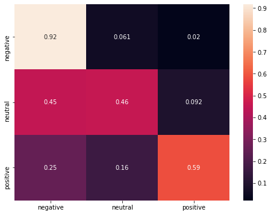

```python
# Confusion matrix
make_confusion_matrix(model_xgb_tfidf, X_val2, y_val2)
```

Metrics improve on validation set, but the model still presents overfitting issues

### 8.4 Tuned XGBoost

Now, we are going to tuned the XGBoost model to improve metrics on validation set

```python
# dictionary with parameters
param_grid = {
    'n_estimators': np.arange(10,200,10),
    'subsample': np.arange(0.1,1,0.1),
    'learning_rate': np.arange(0.1,2,0.1),
    'gamma': np.arange(0.1,3,0.1),
    'colsample_bytree': np.arange(0.1,1,0.1),
    'colsample_bylevel': np.arange(0.1,1,0.1),
}

# Run random search
grid_obj = RandomizedSearchCV(estimator=model_xgb_tfidf, param_distributions=param_grid, n_iter=50, scoring='accuracy',
                              cv=5, random_state=1, n_jobs = -1, verbose=2)
grid_obj.fit(X_train2, y_train2)

# Get the best combination of parameters
xgb_estimator_tf = grid_obj.best_estimator_

# Fit the best algorithm to the data.
xgb_estimator_tf.fit(X_train2, y_train2)
```

```
Fitting 5 folds for each of 50 candidates, totalling 250 fits
```

```
XGBClassifier(base_score=0.5, booster='gbtree', colsample_bylevel=0.1,
              colsample_bynode=1, colsample_bytree=0.6, eval_metric='logloss',
              gamma=0.7000000000000001, gpu_id=-1, importance_type='gain',
              interaction_constraints='', learning_rate=0.4, max_delta_step=0,
              max_depth=6, min_child_weight=1, missing=nan,
              monotone_constraints='()', n_estimators=170, n_jobs=8,
              num_parallel_tree=1, objective='multi:softprob', random_state=1,
              reg_alpha=0, reg_lambda=1, scale_pos_weight=None, subsample=0.8,
              tree_method='exact', validate_parameters=1, verbosity=None)
```

```python
# Result metrics
results_tfidfvec_tuned = metrics_score(xgb_estimator_tf, 'Tf-IDF Vectorizer Tuned XGBoost', X_train2, y_train2, X_val2, y_val2)
results_tfidfvec_tuned
```

|  | Model | Accuracy on training set | Accuracy on validation set | Recall on training set | Recall on validation set | Precision on training set | Precision on validation set | F1 on training set | F1 on validation set |
| --- | --- | --- | --- | --- | --- | --- | --- | --- | --- |
| 0 | Tf-IDF Vectorizer Tuned XGBoost | 0.89249 | 0.771654 | 0.843209 | 0.665272 | 0.882049 | 0.715945 | 0.860892 | 0.685805 |

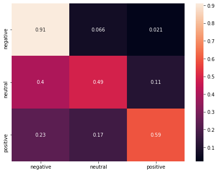

```python
# Confusion matrix
make_confusion_matrix(xgb_estimator_tf, X_val2, y_val2)
```

This model improves accuracy on validation set

## 9 Model performances on test set

Now, we are going to compare all models on test set

```python
# Function to calculate different metric scores of the classification model
def metrics_score_test(model,test,test_y,model_name=''):
    '''
    Inputs:
        model: classifier to predict values of X
        test: Independent features in test sets
        test_y: Dependent variable in test sets
        threshold: thresold for classifiying the observation as 1
        model_name: Name of the model
    '''

    # Make the prediction of the model in train and test sets
    pred_test = model.predict(test)

    # Calculate scores and save them in a dictionary
    score_dict = {'Model':model_name,
                  'Accuracy on test set': accuracy_score(pred_test,test_y),
                  'Recall on test set': recall_score(test_y,pred_test,average='macro'),
                  'Precision on test set': precision_score(test_y,pred_test,average='macro'),
                  'F1 on test set': f1_score(test_y,pred_test,average='macro')
                 }

    # Create a dataframe with scores
    scores = pd.DataFrame(score_dict,index=[0])
    # return the df
    return scores
```

```python
# Create dataframe with scores on Test dataset for all models
all_scores = pd.concat(
    [# Count Vectorizer Models
     metrics_score_test(model_rf_count,X_test,y_test,model_name='Random Forest Count Vectorizer'),
     metrics_score_test(model_xgb_count,X_test,y_test,model_name='XGBoost Count Vectorizer'),
     metrics_score_test(xgb_estimator,X_test,y_test,model_name='Tuned XGBoost Count Vectorizer'),
     # Tf-IDF Vectorizer Models
     metrics_score_test(model_rf_tfidf,X_test2,y_test2,model_name='Random Forest Tf-IDF Vectorizer'),
     metrics_score_test(model_xgb_tfidf,X_test2,y_test2,model_name='XGBoost Tf-IDF Vectorizer'),
     metrics_score_test(xgb_estimator_tf,X_test2,y_test2,model_name='Tuned XGBoost Tf-IDF Vectorizer'),

    ],
    axis=0,
    ignore_index=True)
all_scores.sort_values(by=['Accuracy on test set'], ascending=False)
```

|  | Model | Accuracy on test set | Recall on test set | Precision on test set | F1 on test set |
| --- | --- | --- | --- | --- | --- |
| 2 | Tuned XGBoost Count Vectorizer | 0.794249 | 0.711891 | 0.745102 | 0.726663 |
| 5 | Tuned XGBoost Tf-IDF Vectorizer | 0.786717 | 0.693863 | 0.743134 | 0.714572 |
| 1 | XGBoost Count Vectorizer | 0.781582 | 0.685289 | 0.733600 | 0.705477 |
| 4 | XGBoost Tf-IDF Vectorizer | 0.775077 | 0.664800 | 0.731733 | 0.690631 |
| 3 | Random Forest Tf-IDF Vectorizer | 0.764807 | 0.629818 | 0.727067 | 0.662238 |
| 0 | Random Forest Count Vectorizer | 0.764122 | 0.657294 | 0.705896 | 0.677128 |

- The tuned XGBoost models on both Count and Tf-IDF Vectorizer presents the better metrics with accuracy above 0.78 on test set

Now, we are going the calculate the confusion matrix for these two models

**Tuned XGBoost Count Vectorizer**

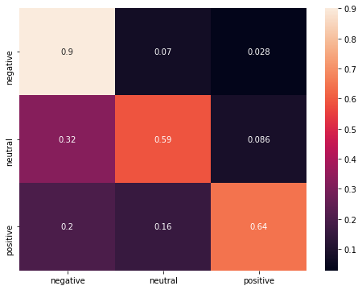

```python
# Confusion matrix
make_confusion_matrix(xgb_estimator, X_test, y_test)
```

**Tuned XGBoost Tf-IDF Vectorizer**

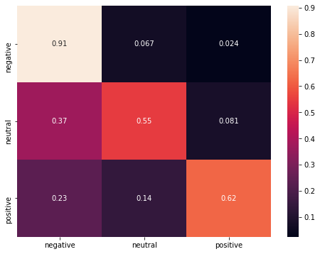

```python
# Confusion matrix
make_confusion_matrix(xgb_estimator_tf, X_test2, y_test2)
```

- Both models presents similar results
- Negative sentiment is correctly determined 90% of the time
- Neutral sentiment is only correctly determined around 55% to 59% of the time
- While, Postive sentiment is correctly determined 62% of the time

## 10 Top 40 features

We are going to use the Tuned XGBoost models to identify the top 40 features

### 10.1 CountVectorizer

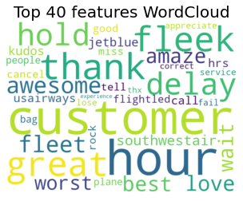

```python
all_features = countvec.get_feature_names()              #Instantiate the feature from the vectorizer
top_features=''                                            # Addition of top 40 feature into top_feature after training the model
feat=xgb_estimator.feature_importances_
features=np.argsort(feat)[::-1]
for i in features[0:40]:
    top_features+=all_features[i]
    top_features+=' '

wordcloud = WordCloud(background_color="white",colormap='viridis',width=800, height=600).generate(top_features)

# Display the generated image:
plt.imshow(wordcloud, interpolation='bilinear')
plt.figure(1, figsize=(20, 15), frameon='equal')
plt.title('Top 40 features WordCloud', fontsize=20)
plt.axis("off")
plt.show()
```

### 10.2 Tf-IDF vectorizer

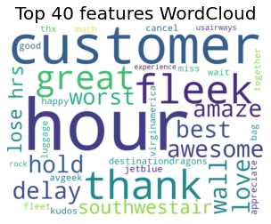

```python
all_features = tfidfvec.get_feature_names()              #Instantiate the feature from the vectorizer
top_features_tf=''                                            # Addition of top 40 feature into top_feature after training the model
feat=xgb_estimator_tf.feature_importances_
features=np.argsort(feat)[::-1]
for i in features[0:40]:
    top_features_tf+=all_features[i]
    top_features_tf+=' '

wordcloud = WordCloud(background_color="white",colormap='viridis',width=800,
                          height=600).generate(top_features_tf)

# Display the generated image:
plt.imshow(wordcloud, interpolation='bilinear')
plt.figure(1, figsize=(20, 15), frameon='equal')
plt.title('Top 40 features WordCloud', fontsize=20)
plt.axis("off")
plt.show()
```

- Both models presents similar top features. The most important are `hour`, `customer`, `great`, `thank` and `fleek`

## 11 Conclusions

- In this project we were able to create a classification model to determine the sentiment of twitter post related to the service of US Airlines
- In order to create an useful data set and model we performed several steps:
  - Data pre-processing: Cleaning the text removing non-text characters and symbols and lemmatize text
  - Convert bag of words on numerical data using CountVectorizer and Tf-IDF vectorizer
  - Fit classifier model. In our project we use Random Forest and XGBoost, but any other classifier model could be used.
- Our models have relatively good accuracy of 78%. We reach this level after we tuned the XGBoost models in order to reduce the overfitting
- Both CountVectorizer and Tf-IDF Vectorizer presents similar results for this specific data set.